# Genetic Variants and Dyslipidemia

Dr. Kari North

02 March, 2017

# Introduction

## Dyslipidemia in children

- Dyslipidemia is an important risk factor for chronic cardiometabolic diseases.
- Dsylipidemia represents any abnormal levels of lipid, lipoprotein, or apolipoprotein factors (Kwiterovich 2008), including:
  - total cholesterol (TC)
  - low density lipoprotein cholesterol (LDL-C)
  - triglycerides (TG)
  - high density lipoprotein choleseterol (HDL-C)

# Introduction

## Heritability of dyslipidemia

- Lipid traits are heritable (h$^2$ can exceed 0.50) (Goode et al. 2007) and strongly associated with cardiovascular disease sustaining strong interest in genetic research.
- By 2013, researchers have identified more than 150 established loci influencing lipid levels in adults (C. J. Willer et al. 2013).

# Introduction

## Lipid variants

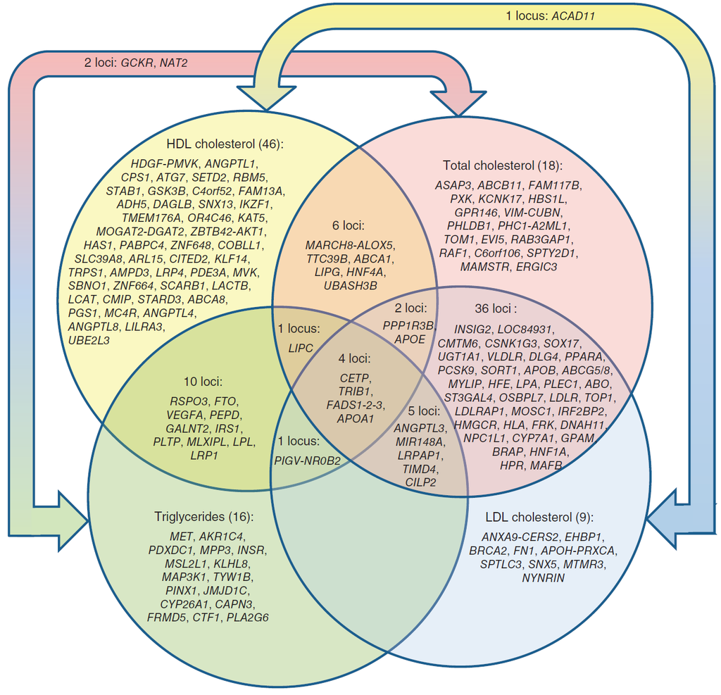

Source: Willer, C. J., Schmidt, E. M., Sengupta, S., Peloso, G. M., Gustafsson, S., Kanoni, S., Abecasis, G. R. (2013). Discovery and refinement of loci associated with lipid levels. Nature Genetics, 45(11), 1274–1283. https://doi.org/10.1038/ng.2797

# Introduction

## Generalizability across ancestral groups

- Results found for adults have been found to generalize to children in a Finnish population (Tikkanen et al. 2011; Buscot et al. 2016).

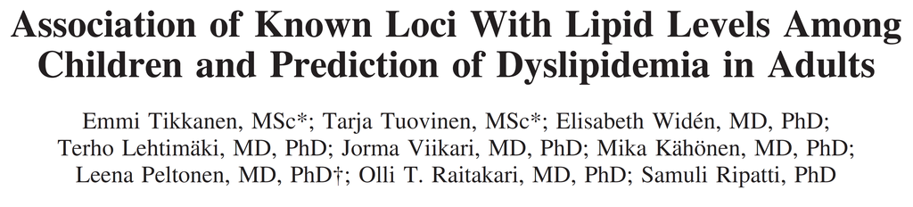

- Certain variants that associate with a trait such as dyslipdemia in one ancestral group may not associate in other groups (Carlson et al. 2013).
  - Why? Differences across ancestral groups include:
    - Variant frequencies
    - Linkage disequilibrium
- No research exists examining the association between genetic variants and dyslipidemia in Hispanic/Latino (HL) children

# Introduction

## Primary Aim

# Methods

## Association tests

- We assessed single variant associations using linear regression for high density lipoprotein cholesterol (HDL-C), low density lipoprotein cholesterol (LDL-C) and triglycerides (TG), assuming an additive genetic model, adjusted for sex and ancestry (via principal components).
- Sample Model for HDL
  - $HDL_i = \beta_0 + SNP_i \beta_1 + sex_i \beta_2 + ANCESTRY_i \boldsymbol{\beta} + \epsilon_i$
  - $SNP_i$ represents one SNP with “genotypes were coded as 0, 1, or 2 when directly genotyped or as a predicted allele dosage (range, 0–2) when imputed.” (Tikkanen et al. 2011)
- Only six variants from the Chilean sample met the *a priori* threshold of power > 0.8 to detect an association based on effect sizes from GWAS (T. M. Teslovich et al. 2010).

# Methods

## Polygenic risk scores

- Regress phenotypes onto weighted trait-specific polygenic risk scores (PRS).
- Sample model for HDL
  - $HDL_i = \beta_0 + \beta_1 PRS1_i + \epsilon_i$
  - PRS for HDL-C
    - (0.48 * rs4660293 + 0.49 * rs2814944 + 0.59 * rs4731702 + 0.41 * rs2923084 + 0.4 * rs7134375 + 0.44 * rs7134594 + 1.45 * rs1532085 + 3.39 * rs3764261 + 0.45 * rs2925979 + 0.42 * rs4148008 + 0.39 * rs4129767 + 0.64 * rs737337 + 1.88 * rs1800961 + 0.93 * rs6065906 + 0.47 * rs1689800 + 0.61 * rs4846914 + 0.68 * rs12328675 + 0.46 * rs2972146 + 0.49 * rs6450176 + 0.39 * rs605066 + 1.95 * rs1084651 + 1.21 * rs9987289 + 0.44 * rs2293889 + 0.65 * rs581080 + 0.94 * rs1883025 + 0.78 * rs3136441 + 0.86 * rs4759375 + 0.44 * rs4765127 + 0.61 * rs838880 + 0.39 * rs2652834 + 1.27 * rs16942887 + 0.48 * rs11869286 + 1.31 * rs7241918 + 0.42 * rs12967135 + 0.45 * rs7255436 + 0.83 * rs386000 + 0.46 * rs181362 + 0.84 * rs13107325) / 29.79
- All PRS are standardized in the regression models: regression coefficient for PRS indicates a one unit change in SD of PRS.

# Methods

## Proportion of variance explained by lipid-related SNPs

- Linear models containing all SNPs related to a specific phenotype, such as HDL-C, will be covariates.
- The continuous lipid phenotype is the outcome.
- Differences in R^2 will be calculated between models with and without the SNPs to estimate h$^2$.
  - Model for HDL:
    - $HDL_i$ = b0 + b1 * rs4660293 + b2 * rs2814944 + b3 * rs4731702 + b4 * rs2923084 + b5 * rs7134375 + b6 * rs7134594 + b7 * rs1532085 + b8 * rs3764261 + b9 * rs2925979 + b10 * rs4148008 + b11 * rs4129767 + b12 * rs737337 + b13 * rs1800961 + b14 * rs6065906 + b15 * rs1689800 + b16 * rs4846914 + b17 * rs12328675 + b18 * rs2972146 + b19 * rs6450176 + b20 * rs605066 + b21 * rs1084651 + b22 * rs9987289 + b23 * rs2293889 + b24 * rs581080 + b25 * rs1883025 + b26 * rs3136441 + b27 * rs4759375 + b28 * rs4765127 + b29 * rs838880 + b30 * rs2652834 + b31 * rs16942887 + b32 * rs11869286 + b33 * rs7241918 + b34 * rs12967135 + b35 * rs7255436 + b36 * rs386000 + b37 * rs181362 + b38 * rs13107325 + $\epsilon_i$

# Results

## Descriptive statistics

| Descriptive statistics by gender, median (interquartile range) Measure | Descriptive statistics by gender, median (interquartile range) | Descriptive statistics by gender, median (interquartile range) Chile n=263 | Descriptive statistics by gender, median (interquartile range) Chile n=283 | Descriptive statistics by gender, median (interquartile range) | Descriptive statistics by gender, median (interquartile range) Finland n=661 | Descriptive statistics by gender, median (interquartile range) Finland n=555 |
| --- | --- | --- | --- | --- | --- | --- |
| log(TG (mmol/l)) |  | 1.44 (0.53) | 1.38 (0.6) |  | 0.900 (0.37) | 0.911 (0.39) |
| LDL-C (mmol/l) |  | 5.26 (1.55) | 5.02 (1.53) |  | 3.07 (0.79) | 2.91 (0.79) |
| HDL-C (mmol/l) |  | 2.3 (0.77) | 2.05 (0.66) |  | 1.55 (0.29) | 1.34 (0.24) |
| TC (mmol/l) |  | 8.55 (1.79) | 7.96 (1.65) |  | 5.02 (0.89) | 4.67 (0.84) |
| Age (years) |  | 16.77 (0.3) | 16.76 (0.31) |  | 18 | 18 |
| BMI (kg/m2) |  | 23.25 (5.33) | 22.31 (5.12) |  | – | – |
| HDL wGRS |  | 33.13 (3.47) | 33.20 (3.42) |  | 32.46 (3.36) | 32.62 (3.41) |
| LDL wGRS |  | 39.96 (6.38) | 39.81 (6.40) |  | 42.1 (6.60) | 41.9 (6.90) |
| TG wGRS |  | 138.84 (17.33) | 138.32 (17.40) |  | 132.71 (16.81) | 131.91 (15.72) |

- Note: All subsequent references to TG refer to log(TG).

# Results

## Explained variance

| Proportion of lipid traits variance explained by lipid-related variants, by gender Gender | Proportion of lipid traits variance explained by lipid-related variants, by gender | Proportion of lipid traits variance explained by lipid-related variants, by gender HDL-C | Proportion of lipid traits variance explained by lipid-related variants, by gender | Proportion of lipid traits variance explained by lipid-related variants, by gender LDL-C | Proportion of lipid traits variance explained by lipid-related variants, by gender | Proportion of lipid traits variance explained by lipid-related variants, by gender TG |
| --- | --- | --- | --- | --- | --- | --- |
| female |  | 0.137 |  | 0.049 |  | 0.125 |
| male |  | 0.199 |  | 0.037 |  | 0.066 |

- The lipid loci explained the least amount of total variance for LDL (males=4% and females=5%) and the most amount of variance for HDL (males=20% and females=14%).

# Results

## Explained variance by gender and country

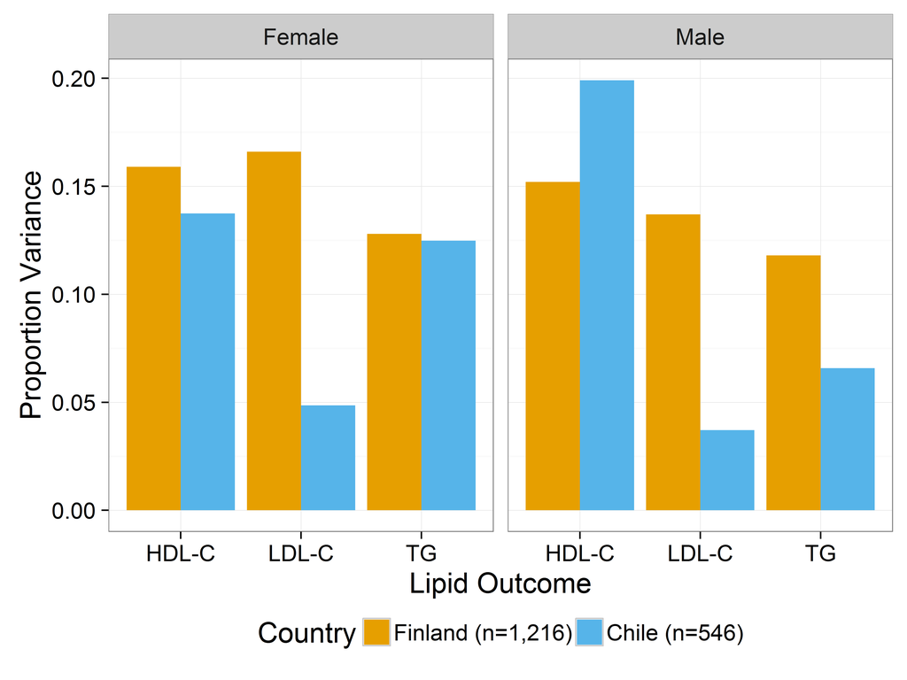

# Results

## Candidate single variant tests of association

| Association between single variants and and serum lipid levels, additive model rsid | Association between single variants and and serum lipid levels, additive model Trait | Association between single variants and and serum lipid levels, additive model Ref/Min allele | Association between single variants and and serum lipid levels, additive model MAF | Association between single variants and and serum lipid levels, additive model Effect (se) | Association between single variants and and serum lipid levels, additive model p-value |
| --- | --- | --- | --- | --- | --- |
| rs3764261 | HDL-C | C/A | 0.31 | 0.158 (0.04) | 1e-04 |
| rs4420638 | LDL-C | A/G | 0.09 | 0.488 (0.133) | 2e-04 |
| rs629301 | LDL-C | T/G | 0.23 | -0.175 (0.092) | 0.0559 |
| rs6511720 | LDL-C | G/T | 0.07 | -0.013 (0.158) | 0.9318 |
| rs1260326 | TG | C/T | 0.31 | 0.042 (0.019) | 0.0254 |
| rs964184 | TG | C/G | 0.37 | 0.042 (0.018) | 0.0224 |
| rs6511720 | TC | G/T | 0.07 | 0.125 (0.165) | 0.4481 |

- For each significant variant, direction of effect matched the multiethnic adult GWAS from which SNPs were selected.

# Results

## Candidate single variant tests of association by variant and country

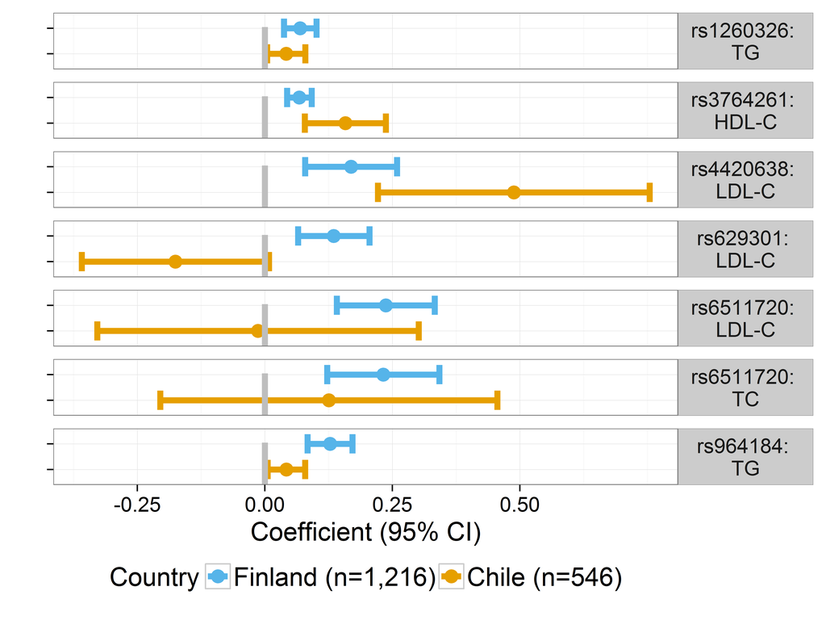

Note: Adjusted for sex of child and first five principal components representing ancestry.

# Results: Weighted polygenic risk score (wPRS) regression coefficients

| Association between the genetic risk score and serum lipid levels, coefficient (SE) Outcome/trait | Association between the genetic risk score and serum lipid levels, coefficient (SE) | Association between the genetic risk score and serum lipid levels, coefficient (SE) Female Not adjusted | Association between the genetic risk score and serum lipid levels, coefficient (SE) Female Adjusted for BMI | Association between the genetic risk score and serum lipid levels, coefficient (SE) | Association between the genetic risk score and serum lipid levels, coefficient (SE) Male Not adjusted | Association between the genetic risk score and serum lipid levels, coefficient (SE) Male Adjusted for BMI |
| --- | --- | --- | --- | --- | --- | --- |
| HDL |  | 0.13 (0.03) | 0.13 (0.03) |  | 0.12 (0.04) | 0.12 (0.04) |
| LDL |  | 0.16 (0.08) | 0.17 (0.08) |  | 0.23 (0.08) | 0.24 (0.08) |
| TG |  | 0.34 (0.15) | 0.08 (0.02) |  | 0.24 (0.13) | 0.05 (0.02) |

- All estimates significant at $\alpha$ level of 0.05 with the exception of TG levels for males.

# Results: Weighted polygenic risk score (wPRS) regression coefficients by country and gender

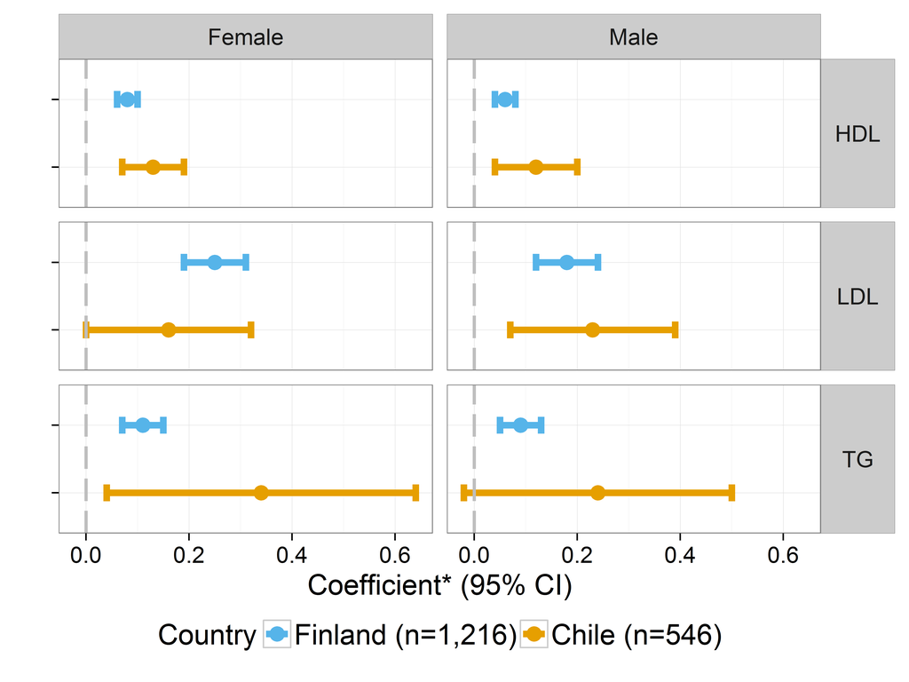

Notes: Coefficients represent change in outcome per 1 SD change in wGRS, adjusted for first five principal components representing ancestry but NOT BMI.

# Conclusion

## Evidence for associations

- There is evidence that lipid loci from a HL sample of adolescents contain similar associations as those from European children and adults.
- Despite the small sample size and possibility for bias with different ancestral groups we found meaningful and statistically significant associations relating lipid loci in a HL cohort of Chilean adolescents with those found in European ancestral groups.
- These associations emphasize the importance of adolescence as a time for disease prevention given studies demonstrating both the persistence of associations between PRS and lipids over the life course and the increasing role PRS plays in predicting disease.

# Extra slides, estimates from Tikkanen et al. (Tikkanen et al. 2011)

## Descriptive statistics

| Descriptive statistics Outcome/Trait | Descriptive statistics | Descriptive statistics Female | Descriptive statistics | Descriptive statistics Male |
| --- | --- | --- | --- | --- |
| N |  | 661 |  | 555 |
| TG (log(mmol/l)) |  | 0.90 (0.37) |  | 0.91 (0.39) |
| LDL-C (mmol/l) |  | 3.07 (0.79) |  | 2.91 (0.79) |
| HDL-C (mmol/l) |  | 1.55 (0.29) |  | 1.34 (0.24) |
| TC (mmol/l) |  | 5.02 (0.89) |  | 4.67 (0.84) |

# Extra slides, estimates from Tikkanen et al. (Tikkanen et al. 2011)

## Proportion variance explained by lipid variants

| Proportion of lipid traits variance explained by lipid-related variants, by gender Gender | Proportion of lipid traits variance explained by lipid-related variants, by gender HDL-C | Proportion of lipid traits variance explained by lipid-related variants, by gender LDL-C | Proportion of lipid traits variance explained by lipid-related variants, by gender TG |
| --- | --- | --- | --- |
| Female | 0.159 | 0.166 | 0.128 |
| Male | 0.152 | 0.137 | 0.118 |

# Extra slides, estimates from Tikkanen et al. (Tikkanen et al. 2011)

## Single variant association tests

| Association between the genetic risk score and serum lipid levels, coefficient (SE) rs id | Association between the genetic risk score and serum lipid levels, coefficient (SE) Trait | Association between the genetic risk score and serum lipid levels, coefficient (SE) Effect (se) | Association between the genetic risk score and serum lipid levels, coefficient (SE) Locus | Association between the genetic risk score and serum lipid levels, coefficient (SE) p-value |
| --- | --- | --- | --- | --- |
| rs3764261 | HDL-C | 0.0676 (0.012) | CETP | 1.5e-08 |
| rs1532085 | HDL-C | 0.0435 (0.011) | LIPC | 6.9e-05 |
| rs6511720 | LDL-C | 0.2370 (0.048) | LDLR | 7.1e-07 |
| rs1260326 | TG | 0.0693 (0.016) | GCKR | 1.7e-05 |
| rs964184 | TG | 0.1278 (0.022) | APOA1-C3-A4-A5 | 5.8e-09 |
| rs6511720 | TC | 0.2320 (0.055) | LDLR | 2.2e-05 |

# Extra slides, estimates from Tikkanen et al. (Tikkanen et al. 2011)

## Polygenic risk score

| Association between the genetic risk score and serum lipid levels, coefficient (SE) Outcome/Trait | Association between the genetic risk score and serum lipid levels, coefficient (SE) | Association between the genetic risk score and serum lipid levels, coefficient (SE) Female | Association between the genetic risk score and serum lipid levels, coefficient (SE) | Association between the genetic risk score and serum lipid levels, coefficient (SE) Male |
| --- | --- | --- | --- | --- |
| HDL |  | 0.08 (0.01) |  | 0.06 (0.01) |
| LDL |  | 0.25 (0.03) |  | 0.18 (0.03) |
| TG |  | 0.11 (0.02) |  | 0.09 (0.02) |

# Extra slides: effect sizes used in PRS from Teslovich et al. 2010 (T. M. Teslovich et al. 2010).

| Locus | Chr | Lead SNP | Lead trait | Other traits | Alleles/MAF | Effect size |
| --- | --- | --- | --- | --- | --- | --- |
| LDLRAP1 | 1 | rs12027135 | TC | LDL | T/A/0.45 | -1.22 |
| PABPC4 | 1 | rs4660293 | HDL |  | A/G/0.23 | -0.48 |
| PCSK9 | 1 | rs2479409 | LDL | TC | A/G/0.30 | 2.01 |
| ANGPTL3 | 1 | rs2131925 | TG | TC, LDL | T/G/0.32 | -4.94 |
| EVI5 | 1 | rs7515577 | TC |  | A/C/0.21 | -1.18 |
| SORT1 | 1 | rs629301 | LDL | TC | T/G/0.22 | -5.65 |
| ZNF648 | 1 | rs1689800 | HDL |  | A/G/0.35 | -0.47 |
| MOSC1 | 1 | rs2642442 | TC | LDL | T/C/0.32 | -1.39 |
| GALNT2 | 1 | rs4846914 | HDL | TG | A/G/0.40 | -0.61 |
| IRF2BP2 | 1 | rs514230 | TC | LDL | T/A/0.48 | -1.36 |
| APOB | 2 | rs1367117 | LDL | TC | G/A/0.30 | 4.05 |
|  | NA | rs1042034 | TG | HDL | T/C/0.22 | -5.99 |
| GCKR | 2 | rs1260326 | TG | TC | C/T/0.41 | 8.76 |
| ABCG5/8 | 2 | rs4299376 | LDL | TC | T/G/0.30 | 2.75 |
| RAB3GAP1 | 2 | rs7570971 | TC |  | C/A/0.34 | 1.25 |
| COBLL1 | 2 | rs10195252 | TG |  | T/C/0.40 | -2.01 |
|  | NA | rs12328675 | HDL |  | T/C/0.13 | 0.68 |
| IRS1 | 2 | rs2972146 | HDL | TG | T/G/0.37 | 0.46 |
| RAF1 | 3 | rs2290159 | TC |  | G/C/0.22 | -1.42 |
| MSL2L1 | 3 | rs645040 | TG |  | T/G/0.22 | -2.22 |
| KLHL8 | 4 | rs442177 | TG |  | T/G/0.41 | -2.25 |
| SLC39A8 | 4 | rs13107325 | HDL |  | C/T/0.07 | -0.84 |
| ARL15 | 5 | rs6450176 | HDL |  | G/A/0.26 | -0.49 |
| MAP3K1 | 5 | rs9686661 | TG |  | C/T/0.20 | 2.57 |
| HMGCR | 5 | rs12916 | TC | LDL | T/C/0.39 | 2.84 |
| TIMD4 | 5 | rs6882076 | TC | LDL, TG | C/T/0.35 | -1.98 |
| MYLIP | 6 | rs3757354 | LDL | TC | C/T/0.22 | -1.43 |
| HFE | 6 | rs1800562 | LDL | TC | G/A/0.06 | -2.22 |
| HLA | 6 | rs3177928 | TC | LDL | G/A/0.16 | 2.31 |
|  | NA | rs2247056 | TG |  | C/T/0.25 | -2.99 |

[output cut: 72 more lines]

# Extra slides: Other work

1. [AHA EPI/Lifestyle 2015 Poster: Childhood body mass index (BMI) z-scores associated with low HDL-C levels in adolescence in a Chilean cohort](http://vonholle.web.unc.edu/files/2015/02/slides.20150226.pdf)
2. [UNC EPID 726 class presentation in advance of AHA predoctoral (successful) grant application (2016-2018)](http://vonholle.web.unc.edu/files/2015/02/slides-epid726-avh-20150409.pdf)
3. [Questions about analyses? Please visit the github web page!](https://github.com/avonholle/ms-201608-1)
4. [Assistance with slides by Ann Von Holle, doctoral student](https://vonholle.web.unc.edu/)

# References

Buscot, Marie-jeanne, Costan G. Magnussen, Markus Juonala, Niina Pitkänen, Terho Lehtimäki, Jorma S. A. Viikari, Mika Kähönen, et al. 2016. “The Combined Effect of Common Genetic Risk Variants on Circulating Lipoproteins Is Evident in Childhood: A Longitudinal Analysis of the Cardiovascular Risk in Young Finns Study.” Edited by David Fardo. *PLOS ONE* 11 (1): e0146081. doi:10.1371/journal.pone.0146081.

Carlson, Christopher S., Tara C. Matise, Kari E. North, Christopher A. Haiman, Megan D. Fesinmeyer, Steven Buyske, Fredrick R. Schumacher, et al. 2013. “Generalization and Dilution of Association Results from European GWAS in Populations of Non-European Ancestry: The PAGE Study.” Edited by Greg Gibson. *PLoS Biology* 11 (9): e1001661. doi:10.1371/journal.pbio.1001661.

Goode, Ellen L., Stacey S. Cherny, Joe C. Christian, Gail P. Jarvik, and Mariza de Andrade. 2007. “Heritability of Longitudinal Measures of Body Mass Index and Lipid and Lipoprotein Levels in Aging Twins.” *Twin Research and Human Genetics* 10 (5): 703–11. doi:10.1375/twin.10.5.703.

Kwiterovich, Peter O. 2008. “Clinical and Laboratory Assessment of Cardiovascular Risk in Children: Guidelines for Screening, Evaluation, and Treatment.” *Journal of Clinical Lipidology* 2 (4): 248–66. doi:10.1016/j.jacl.2008.06.003.

Teslovich, Tanya M., Kiran Musunuru, Albert V. Smith, Andrew C. Edmondson, Ioannis M. Stylianou, Masahiro Koseki, James P. Pirruccello, et al. 2010. “Biological, Clinical and Population Relevance of 95 Loci for Blood Lipids.” *Nature* 466 (7307): 707–13. doi:10.1038/nature09270.

Tikkanen, E., T. Tuovinen, E. Widen, T. Lehtimaki, J. Viikari, M. Kahonen, L. Peltonen, O. T. Raitakari, and S. Ripatti. 2011. “Association of Known Loci with Lipid Levels Among Children and Prediction of Dyslipidemia in Adults.” *Circulation: Cardiovascular Genetics* 4 (6): 673–80. doi:10.1161/CIRCGENETICS.111.960369.

Willer, Cristen J, Ellen M Schmidt, Sebanti Sengupta, Gina M Peloso, Stefan Gustafsson, Stavroula Kanoni, Andrea Ganna, et al. 2013. “Discovery and Refinement of Loci Associated with Lipid Levels.” *Nature Genetics* 45 (11): 1274–83. doi:10.1038/ng.2797.